# Assignment 1 - Visualize This

#### **Question**: DDG2P: mutation consequence와 organ specificity의 연관성에 따른 pLI 분석

#### **Data**: The Development Disorders Genotype-Phenotype Database(DDG2P)

## **Introduction**

’The Development Disorders Genotype-Phenotype Database(DDG2P)’란 ’developmental disorders’와 연관된 것으로 보고된 gene들의 curated list이다. 이는 ’DDD(Deciphering Development Disorders) study’의 한 부분으로서 likely causal variants를 분석하기 위해 편집된 data이다.

(Source: [DECIPHER](https://decipher.sanger.ac.uk/ddd#overview))

## **Loading Packages**

데이터 분석에 필요한 package들을 load해준다.

```r
install.packages("tidyverse")
library(tidyverse)
install.packages("dslabs")
library(dslabs)
library(dplyr)
library(ggplot2)
install.packages("ggthemes")
library(ggthemes)
```

## **Loading Data**

`DDG2P` data를 `read.delim` function을 이용하여 R object로 저장해준다.

```r
ddg2p <- read.delim("DDG2P_24_9_2019.with_pLI.txt", header = T, sep = "\t")
```

## **Purpose of the project**

자료 분석 주제를 정하기 위해 `head` function을 사용하여 자료를 살펴본다.

```r
head(ddg2p)
```

|  | gene.symbol | gene.mim | disease.name | disease.mim | DDD.category | allelic.requirement | mutation.consequence | phenotypes | organ.specificity.list | pmids | panel | prev.symbols | hgnc.id | gene.disease.pair.entry.date | pLI | pRec | pNull |
| --- | --- | --- | --- | --- | --- | --- | --- | --- | --- | --- | --- | --- | --- | --- | --- | --- | --- |
| 1 | AAAS | 605378 | ACHALASIA-ADDISONIANISM-ALACRIMA SYNDROME | 231550 | confirmed | biallelic | loss of function | HP:0000972;HP:0001249;HP:0004322;HP:0001251;HP:0002571;HP:0001263;HP:0001324;HP:0000649;HP:0002459;HP:0007002;HP:0009916;HP:0003487;HP:0008259;HP:0001347;HP:0000648;HP:0000953;HP:0001278;HP:0000007;HP… | Face;Endocrine/Metabolic;Eye | 11159947;18628786;11701718;11062474;15173230 | DD | NA | 13666 | 2015-07-22 16:14:45 | 4.542872e-10 | 0.792914349 | 2.070857e-01 |
| 2 | AARS | No gene mim | EARLY-ONSET EPILEPTIC ENCEPHALOPATHY WITH PERSISTENT MYELINATION DEFECT. | No disease mim | probable | biallelic | loss of function | NA | Brain/Cognition | 25817015 | DD | NA | 20 | 2015-07-22 16:14:53 | 4.678315e-05 | 0.999939422 | 1.379508e-05 |
| 3 | AASS | 605113 | HYPERLYSINEMIA | 238700 | probable | biallelic | loss of function | HP:0000007;HP:0001903;HP:0001249;HP:0001083;HP:0001252;HP:0002161;HP:0000119;HP:0001250 | Endocrine/Metabolic;Brain/Cognition | 934735;10775527 | DD | NA | 17366 | 2015-07-22 16:14:48 | 1.355315e-06 | 0.997781398 | 2.217247e-03 |
| 4 | ABCB11 | 603201 | ABCB11-RELATED INTRAHEPATIC CHOLESTASIS | 601847 | confirmed | biallelic | loss of function | HP:0003155;HP:0004322;HP:0003819;HP:0001508;HP:0002240;HP:0002908;HP:0001402;HP:0000989;HP:0000007;HP:0003593;HP:0001046;HP:0001406;HP:0002014;HP:0001394;HP:0001744;HP:0002630 | GI tract | 10579978;9806540;16039748 | DD | BSEP;PFIC2 | 42 | 2015-07-22 16:14:39 | 2.188495e-10 | 0.998263927 | 1.736073e-03 |
| 5 | ABCB6 | 605452 | MICROPHTHALMIA, ISOLATED, WITH COLOBOMA 7 | 614497 | possible | monoallelic | all missense/in frame | HP:0000568;HP:0000006 | Eye | 22226084 | DD | NA | 47 | 2015-07-22 16:14:27 | 2.111322e-17 | 0.049799963 | 9.502000e-01 |
| 6 | ABCB7 | 300135 | ANEMIA, SIDEROBLASTIC, WITH ATAXIA | 301310 | confirmed | hemizygous | all missense/in frame | HP:0002470;HP:0001310;HP:0001939;HP:0004840;HP:0002075;HP:0002080;HP:0001260;HP:0002169;HP:0003487;HP:0001419;HP:0001347;HP:0003621 | Bone Marrow/Immune;Brain/Cognition | NA | DD | ABC7 | 48 | 2015-07-22 16:15:01 | 9.950478e-01 | 0.004952071 | 1.060450e-07 |

필자는 `DDG2P` data의 17가지 column들을 살펴보던 중, 특정한 organ에서는 소수의 특정 gene들이 큰 영향을 줄 것인데, 이 gene에 특정한 mutation이 일어났을 때 어떤 organ이 얼마나 영향을 받는지에 대한 궁금증이 생겼다. 또한 gene에 specific한 값인 pLI score에 대해서도 함께 분석해보고자 하는 호기심이 생겼다. 따라서 “`gene`에서 발생한 `mutation consequence`와 `organ specificity`가 어떤 연관성을 가지고 있으며, 그에 따라 `pLI` 값은 어떤 양상을 보이는가?”에 대하여 분석해보고자 한다.

## **Studying Data**

주제에 따라 `DDG2P` 자료에서 필자가 다룰 column은 `gene.symbol`, `mutation.consequence`, `organ.specificity.list`, `pLI` 이다.

본격적인 data 분석을 시작하기 전, 각 column과 그에 속하는 item들에 대해 알아보자.

첫번째로 `mutation.consequence`에 속한 item들을 살펴보겠다.

```r
ddg2p %>% group_by(mutation.consequence) %>% count() %>% arrange(desc(n))
```

[output not shown]

| mutation.consequence | n |
| --- | --- |
| loss of function | 1589 |
| all missense/in frame | 415 |
| uncertain | 148 |
| activating | 125 |
| dominant negative | 53 |
| NA | 25 |
| cis-regulatory or promotor mutation | 10 |
| 5_prime or 3_prime UTR mutation | 6 |
| gain of function | 6 |
| increased gene dosage | 3 |

[output cut: 1 more lines]

- **`loss of function`**

  Nonsense, frame-shifting indel, essential splice site mutation, whole gene deletion or any other mutation where functional analysis demonstrates clear reduction or loss of function (Source: [Definitions of the terms used in the database](https://decipher.sanger.ac.uk/files/ddd/ddg2p_definitions_of_terms.pdf))
- **`all missense/in frame`**

  Where all the mutations described in the data source are either missense or in frame deletions and there is no evidence favoring either loss-of-function, activating or dominant negative effect (Source: [Definitions of the terms used in the database](https://decipher.sanger.ac.uk/files/ddd/ddg2p_definitions_of_terms.pdf))
- **`uncertain`**

  Where the exact nature of the mutation is unclear or not recorded (Source: [Definitions of the terms used in the database](https://decipher.sanger.ac.uk/files/ddd/ddg2p_definitions_of_terms.pdf))
- **`activating`**

  Mutation, usually missense that results in a constituative functional activation of the gene product (Source: [Definitions of the terms used in the database](https://decipher.sanger.ac.uk/files/ddd/ddg2p_definitions_of_terms.pdf))
- **`dominant negative`**

  Mutation within one allele of a gene that creates a significantly greater deleterious effect on gene product function than a monoallelic loss of function mutation (Source: [Definitions of the terms used in the database](https://decipher.sanger.ac.uk/files/ddd/ddg2p_definitions_of_terms.pdf))
- **`cis-regulatory or promotor mutation`**

  Mutation in cis-regulatory elements that lies out with the known transcription unit and promotor of the controlled gene (Source: [Definitions of the terms used in the database](https://decipher.sanger.ac.uk/files/ddd/ddg2p_definitions_of_terms.pdf))
- **`5_prime or 3_prime UTR mutation`**

  Mutation occured at 5’ UTR or 3’ UTR. 5’ UTR is the portion of an mRNA from the 5’ end to the position of the first codon used in translation. The 3’ UTR is the portion of an mRNA from the 3’ end of the mRNA to the position of the last codon used in translation. (Source: [Definition of the UTR](http://groups.molbiosci.northwestern.edu/holmgren/Glossary/Definitions/Def-U/UTR.html))
- **`gain of function`**

  Mutation, usually missense that results in a constituative functional activation of the gene product `gain of function’은 ’activating’과 같은 mutation이다. (Source: [Definitions of the terms used in the database](https://decipher.sanger.ac.uk/files/ddd/ddg2p_definitions_of_terms.pdf))
- **`increased gene dosage`**

  Copy number variation that increases the functional dosage of the gene (Source: [Definitions of the terms used in the database](https://decipher.sanger.ac.uk/files/ddd/ddg2p_definitions_of_terms.pdf))

결과적으로 `mutation.consequence`에는 총 10가지 mutation consequence가 item으로 존재함을 알 수 있다.

두번째로 `organ.specificity.list`에 속한 item들을 살펴보겠다.

```r
head(ddg2p$organ.specificity.list)
```

```
[1] Face;Endocrine/Metabolic;Eye
[2] Brain/Cognition
[3] Endocrine/Metabolic;Brain/Cognition
[4] GI tract
[5] Eye
[6] Bone Marrow/Immune;Brain/Cognition
348 Levels: Bone Marrow/Immune ...
```

우선 `organ.spscificity.list` column을 살펴보면 한 gene이 해당 mutation consequence에 대하여 여러가지 organ specificity를 가지는데, 이게 한꺼번에 하나의 row에 쓰인 경우가 존재한다. 따라서 `separate_rows` function을 사용하여 이 organ specificity 정보를 개별의 row로 변환해준다. (`organ.specificity.list`에 속하는 item들을 살펴본 결과, `/`, `%`, `:`는 어떠한 organ인지에 대한 정보를 좁혀주는 용도로 사용되었으므로 separate하면 안된다.)

```r
ddg2p_tidy <- ddg2p %>% separate_rows(organ.specificity.list, sep = ';')
```

이제 item들을 살펴보자.

```r
ddg2p_tidy %>% group_by(organ.specificity.list) %>% count() %>% arrange(desc(n))
```

| organ.specificity.list | n |
| --- | --- |
| Brain/Cognition | 1402 |
| Skeleton | 697 |
| Endocrine/Metabolic | 456 |
| Eye | 334 |
| Face | 261 |
| Heart/Cardiovasculature/Lymphatic | 250 |
| Skin | 240 |
| GI tract | 157 |
| Kidney Renal Tract | 149 |
| Ear | 141 |

[output cut: 16 more lines]

이렇게 총 25가지 organ이 item으로 존재함을 알 수 있다.

세번째로 `pLI`라는 이름의 column에 들어있는 `pLI score`에 대해 알아보겠다. `pLI score`이란 ’특정 유전자에 loss of function이 발생했을 때 정상적으로 작동하지 않을 확률’이다. 따라서 `pLI score`이 높은 유전자는 약간의 돌연변이가 발생하더라도 유전자에 큰 영향을 미칠 확률이 높다고 해석할 수 있다. 또한 `pLI score`에서 유의할 점은, 이 값은 **gene specific**하며 다른 mutation이 아닌 **‘loss of function’**과만 관련이 있는 값이라는 사실이다.

(Source: [DECIPHER](https://decipher.sanger.ac.uk/info/loss-intolerance))

그럼 이제 각 column에 대한 분석이 끝났으니, 필자가 알아보고자 하는 주제에 대한 분석을 시작하겠다.

## **Analyzing Data**

데이터를 분석하는 동안 orginal한 자료를 해칠 수 있으므로, 필요한 column들만 간추려 `p`라는 새로운 data frame을 만든다.

```r
p <- ddg2p_tidy %>% select(gene.symbol, mutation.consequence, organ.specificity.list, pLI)
```

그리고 `Studying data`에서 알아본대로, `mutation.consequence`에서 ’activating’과 ’gain of function’은 같은 mutation consequence이므로 ’gain of function’을 모두 ’activating’으로 바꿔 통일해준다. 또한 `NA`들은 빈도수를 비교함에 있어서는 무의미하므로 모두 삭제해준다.

```r
p <- p %>% filter(!is.na(mutation.consequence) & !is.na(organ.specificity.list)) %>% mutate(mutation.consequence = gsub('gain of function', 'activating', mutation.consequence))
```

### **Analysis 1**

: 어떤 mutation consequence가 일어났을 때 어떤 organ이 specific하게 영향을 받았는지 빈도수를 summarize해봄으로써 알아보자.

그 전에 `mutation.consequence`에서 `uncertain`이라는 item에 대해 먼저 생각해보자. `uncertain` mutation의 정의는 ’Where the exact nature of the mutation is unclear or not recorded’이다. 필자는 `organ.specificity.list`를 사용하여 data `p`를 grouping하고 빈도수를 계산할 것이다. 이 때, `uncertain` mutation에 해당하는 row들은 모두 mutation의 이유가 unclear하거나 not recorded하여 동일한 mutation이 아님에도 불구하고 하나의 category로 빈도수가 측정된다. 이는 data 분석에 있어 왜곡을 줄 수 있으므로 `filter` function을 사용하여 data에서 걸러준다.

```r
a <- p %>% filter(!mutation.consequence == 'uncertain') %>% group_by(mutation.consequence, organ.specificity.list) %>% count() %>% arrange(desc(n))
a
```

| mutation.consequence | organ.specificity.list | n |
| --- | --- | --- |
| loss of function | Brain/Cognition | 980 |
| loss of function | Skeleton | 444 |
| loss of function | Endocrine/Metabolic | 367 |
| all missense/in frame | Brain/Cognition | 247 |
| loss of function | Eye | 236 |
| loss of function | Face | 159 |
| loss of function | Skin | 148 |
| loss of function | Heart/Cardiovasculature/Lymphatic | 138 |
| loss of function | Kidney Renal Tract | 132 |
| loss of function | GI tract | 130 |

[output cut: 92 more lines]

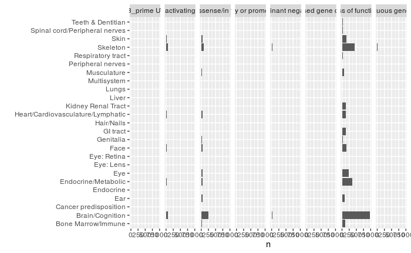

```r
a %>% ggplot(aes(x = organ.specificity.list, y = n)) + geom_bar(stat = "identity") + coord_flip() + xlab("") + facet_grid(~mutation.consequence)
```

새로 생성한 data `a`를 가지고 plot을 만든 결과 `loss of function`, `all missense/in frame`, `activating`에 해당하는 row의 수가 압도적이어서 data의 분포 파악이 어렵다는 것을 알 수 있다. 따라서 그 외의 `mutation.consequence`에 해당하는 item들은 `others`라는 이름으로 묶어주도록 한다.

```r
b <- p %>% filter(!mutation.consequence == 'uncertain') %>% mutate(mutation.consequence = gsub('dominant negative', 'others', mutation.consequence)) %>% mutate(mutation.consequence = gsub('cis-regulatory or promotor mutation', 'others', mutation.consequence)) %>% mutate(mutation.consequence = gsub('5_prime or 3_prime UTR mutation', 'others', mutation.consequence)) %>% mutate(mutation.consequence = gsub( 'increased gene dosage', 'others', mutation.consequence)) %>% mutate(mutation.consequence = gsub('part of contiguous gene duplication', 'others', mutation.consequence)) %>% group_by(mutation.consequence, organ.specificity.list) %>% count() %>% arrange(desc(n))
b
```

| mutation.consequence | organ.specificity.list | n |
| --- | --- | --- |
| loss of function | Brain/Cognition | 980 |
| loss of function | Skeleton | 444 |
| loss of function | Endocrine/Metabolic | 367 |
| all missense/in frame | Brain/Cognition | 247 |
| loss of function | Eye | 236 |
| loss of function | Face | 159 |
| loss of function | Skin | 148 |
| loss of function | Heart/Cardiovasculature/Lymphatic | 138 |
| loss of function | Kidney Renal Tract | 132 |
| loss of function | GI tract | 130 |

[output cut: 75 more lines]

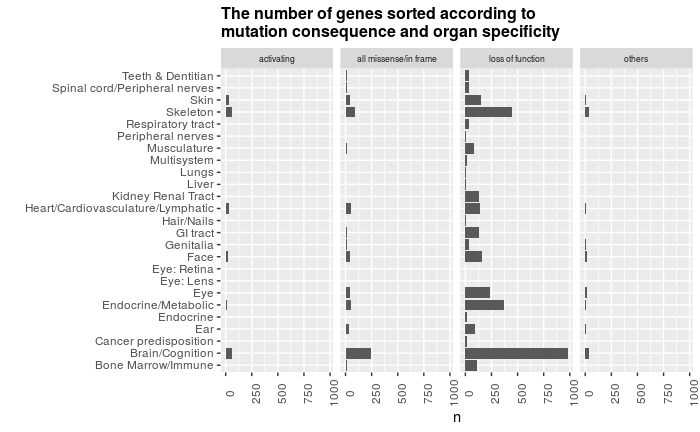

```r
analysis_1 <- b %>% ggplot(aes(x = organ.specificity.list, y = n)) + geom_bar(stat = "identity") + coord_flip() + xlab("") + facet_grid(~mutation.consequence) + ggtitle("The number of genes sorted according to \nmutation consequence and organ specificity") + theme(plot.title = element_text(size = 12, face = "bold"), axis.text.x = element_text(angle = 90), strip.text.x = element_text(size = 6.5))
analysis_1
ggsave("analysis_1.pdf", analysis_1)
```

### **Analysis 2**

: 이에 대한 pLI 값의 관련성

앞서 공부한 내용에 따르면, `pLI score`란 ’특정 유전자에 loss of function이 발생했을 때 정상적으로 작동하지 않을 확률’이므로 gene에 specific한 값임을 알 수 있다. 그러나 필자는 이 사실을 한 번 더 확인하기 위해 같은 `gene.symbol`에 대해 다른 `pLI` 값을 가지는 경우가 있는지 확인하겠다.

```r
ddg2p %>% group_by(gene.symbol, pLI) %>% count() %>% nrow()
```

```
[1] 1801
```

```r
ddg2p %>% group_by(gene.symbol) %>% count() %>% nrow()
```

```
[1] 1801
```

다음과 같이 두 count 결과의 row 수는 1,801개로 동일하다. 따라서 pLI란 gene에 specific한 값임이 한 번 더 증명되었다.

또한 `pLI score`에서 유의할 점은, 이 값은 다른 mutation이 아닌 ‘loss of function’과만 관련이 있는 값이라는 사실이다. 따라서 `mutation.consequence`가 ’loss of function’인 row들만 걸러준다. 그리고 필자는 특정 organ에 영향을 주는 gene들의 pLI값의 평균을 냄으로써 어떠한 organ에서 ’loss of function’ mutation이 일어났을 때 제일 정상적으로 작동하지 않을지에 대해 알아볼 것이다.

plot을 제작하기에 앞서, organ별로 lof가 일어난 gene들의 pLI score의 평균을 내어, `organ.specificity.list`에 대하여 pLI score의 평균인 `avg_pLI`를 가지는 `pLI_organ`이라는 이름의 data frame을 만들어준다.

```r
pLI_organ <- p %>% filter(mutation.consequence == 'loss of function') %>% group_by(organ.specificity.list) %>% summarize(avg_pLI = mean(pLI)) %>% mutate(organ.specificity.list = reorder(organ.specificity.list, avg_pLI))
pLI_organ
```

| organ.specificity.list | avg_pLI |
| --- | --- |
| Bone Marrow/Immune | 2.928501e-01 |
| Brain/Cognition | 4.162128e-01 |
| Cancer predisposition | 4.607068e-01 |
| Ear | 3.609885e-01 |
| Endocrine | 4.737921e-01 |
| Endocrine/Metabolic | 1.952849e-01 |
| Eye | 2.965655e-01 |
| Eye: Lens | 3.896819e-11 |
| Eye: Retina | 1.030243e-08 |
| Face | 6.514830e-01 |

[output cut: 15 more lines]

그리고 이 data frame을 사용하여 barplot을 생성한다.

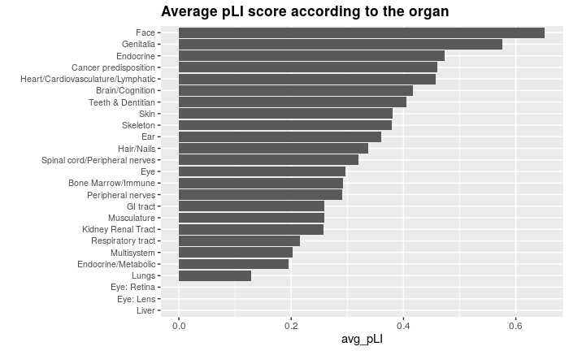

```r
analysis_2 <- pLI_organ %>% ggplot(aes(x = organ.specificity.list, y = avg_pLI)) + geom_bar(stat = 'identity') + coord_flip() + theme(axis.text.y = element_text(size = 6)) + xlab("") + ggtitle("Average pLI score according to the organ") + theme(plot.title = element_text(size = 13, face = "bold"), axis.text.y = element_text(size = 8))
analysis_2
ggsave("analysis_2.pdf", analysis_2)
```

## **Conclusion**

분석하고자 했던 내용을 담은 plot을 모두 생성했으므로, 이젠 그로 인해 알아낼 수 있는 사실들을 정리해보겠다.

### **Analysis 1**

이 plot을 통해서는 각 `organ`에 specific하게 작용하는 `gene`들에 어떠한 `mutation consequence`가 가장 많이 발생하여 developmental disorder에 영향을 주었는지, 또는 각 `mutation consequence`가 일어난 `gene`들이 어떤 `organ`에 가장 specific하게 영향을 주어 developmental disorder이 나타났는지를 알 수 있다.

우선 developmental disorder에 연관이 있는 gene들에는 8가지 `mutation consequence` 중 **loss of function**이 압도적으로 많이 발생했음을 단번에 알 수 있다. 그리고 **loss of function**이라는 mutation이 발생하여 **Brain/Cognition**이라는 organ이 영향을 받아 developmental disorder에 영향을 주는 gene이 제일 많다는 사실을 알 수 있다.

### **Analysis 2**

`pLI score`이 높은 유전자는 약간의 돌연변이가 발생하더라도 유전자에 큰 영향을 미칠 확률이 높다는 사실을 `Studying data`를 통해 알고있다.

`Face`라는 organ에 영향을 주는 gene들은 상대적으로 높은 `pLI score`을 가져(higher than 0.65) lof가 발생하면 이 유전자에 큰 영향을 미쳐 `Face`에 developmental disorder을 가지게 될 가능성이 높다.

반면 `Liver`, `Eye:Lens`, `Eye:Retina`라는 organ에 영향을 주는 gene들은 low pLI score(pLI ≤ 0.1)을 가져 lof가 발생해도 이 유전자에 작은 영향을 미쳐 각 organ에 developmental disorder을 가지게 될 가능성이 낮다.

### **Limitation**

`Analysis 2`에서 필자는 `pLI` 값의 평균을 내었다. 그러나 data를 분석하던 중 `avg_pLI`라는 값이 유효한 값인가 생각해 볼 필요가 있다는 사실을 깨달았다.

기존의 `ddg2p` data에서 `pLI score`을 살펴보면,

```r
max(ddg2p$pLI)
min(ddg2p$pLI)
```

[output not shown]

이와 같이 최대값은 1, 최소값은 3.38323e-52로 차이가 굉장이 크다. 만약 평균값을 낼 대상인 자료의 대부분이 매우 작은 `pLI score`에 해당한다 하더라도 `pLI score`가 1인 gene이 자료에 포함되어 있다면 평균값은 굉장히 커질 것이다.

이처럼 평균을 내려하는 자료의 `pLI score`들의 크기가 천차만별이므로 단순히 평균을 내는 것은 분석에 왜곡을 줄 수 있다. 따라서 자료의 분산까지 고려한 방식을 고안하여 계산하는 것이 더 유효한 결과를 낼 수 있을 것이다.

### **Feedback**

1. “그러나 단점으로는 우선 색이 흑백으로만 되어있어 굉장히 단조롭고, mutation consequence가 너무 빼곡하게 배열되어있다.”

-반영하여 color을 입히고 facet grid 대신 geom_bar을 사용해보기로 한다.

2. “또한, lof의 경우 n이 1000 까지도 나타나기 때문에 0에서 1000 까지의 범위를 잡는 것이 적절하지만, activating, others는 가장 빈도가 높은 데이터도 250에 미치지 못하기 때문에 1000으로 범위를 잡는 것은 적절하지 못하기 때문에 범위를 재조정하여 데이터를 나타냈으면 더 좋았을 것 같다.” “다만, 같은 선상에서 lof만 범위를 다르게 한다면 관찰자가 수치를 해석할 때 오류를 범할 가능성이 있으므로 범위가 다름을 나타낼 수 있도록 해야 한다. 예를 들어 lof와 action+others를 row를 구분하여 두 줄의 layout으로 표현하는 등의 방법이 있을 것이다.”

-그러나 다른 선상에 두고 범위를 다르게 한다고 해도 관찰자의 수치 해석에 방해가 된다고 생각하기에 반영하지 않는다.

3. “아쉬운 점은 y 축의 label이 너무 긴 경우이다. 대신에 축약어를 사용해 간략하게 나타내는 것이 깔끔해 보일 것이다. 또 유의미한 값이 brain/cognition인 만큼 해당 데이터만 다른 색으로 지정해 나타낸다면 말하고자 하는 바를 한번에 활실하게 전할 수 있을 것이다.”

-축약어를 사용하는 것은 오히려 plot 해석에 있어 문제가 발생할 수 있으므로 반영하지 않는다.

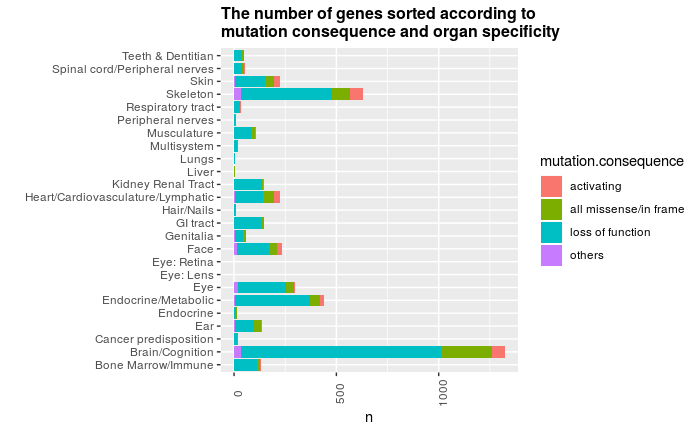

```r
analysis_1 <- b %>% ggplot(aes(x = organ.specificity.list, y = n, fill = mutation.consequence)) + geom_bar(stat = "identity") + coord_flip() + xlab("") + ggtitle("The number of genes sorted according to \nmutation consequence and organ specificity") + theme(plot.title = element_text(size = 12, face = "bold"), axis.text.x = element_text(angle = 90), strip.text.x = element_text(size = 6.5))
analysis_1
ggsave("analysis_1.pdf", analysis_1)
```